# CreditCard

Ted

2018年7月31日

[資料庫來源](https://www.kaggle.com/uciml/default-of-credit-card-clients-dataset)

## 問題

- 拖欠付款的機率和什麼變項有關?
- 可不可以透過變數來預測一個人會不會拖欠付款?

這些問題關係到銀行要讓哪種人貸款比較安全(會準時還款)

1. 教育程度比較高的人比較不會欠款?
2. 女生較男生不容易欠款?
3. 未婚的人比較可能欠款?

## 原始資料變數解釋

**我用來分析的變數**

LIMIT_BAL:信用額度

SEX 性別(1 = male; 2 = female).

Education教育程度 (1 = graduate school; 2 = university; 3 = high school; 0, 4, 5, 6 = others).

Marital status婚姻狀態 (1 = married; 2 = single; 3 = divorce; 0=others).

Age 年齡(year)

default payment next month: 是否拖延繳款(1 = 是, 0 = 否)

**以下變數因為和我有興趣的問題較不相關所以暫時不使用**

Pay_0~6:過去一個月的繳款紀錄(依序為2005-09 ~ 2005-04).

- -2 沒有用信用卡消費No consumption
- -1 全部繳清Paid in full
- 0 使用循還信貸The use of revolving credit
- 1 拖延繳款1個月payment delay for one month
- 2 拖延繳款2個月payment delay for two months
- 以此類推
- 9 拖延繳款9個月以上(含九個月)payment delay for nine months and above

BILL_AMT1~6 信用卡帳單(依序為2005-09 ~ 2005-04)

PAY_AMT1~6 前期付費(依序為2005-09 ~ 2005-04)

```r
# 讀取資料
library(tidyr)
library(stringr)
path =  "C:\\Users\\B06408042\\Desktop\\GitHub\\CSX_RProject_summer_2018\\week4\\UCI_Credit_Card.csv"
TB = read.csv(path)


# 因為教育一欄中0456都代表others，所以將這些欄位置換以免影響分析
TB$EDUCATION = str_replace_all(TB$EDUCATION, c("5" = "0", "6" = "0", "4" = "0"))


# 轉成factor
TB$ID = factor(TB$ID)
TB$SEX = factor(TB$SEX, labels = c("male", "female"))
TB$EDUCATION = factor(TB$EDUCATION, labels = c("others","graduate school", "university", "high school"))
TB$MARRIAGE = factor(TB$MARRIAGE, labels = c("others","married", "single","divorce"))
TB$AGE = factor(TB$AGE)
TB$PAY_0 = factor(TB$PAY_0, labels = c("No consumption", "Paid in full", "use revolving credit", "delay 1 month", "delay 2 month","delay 3 month","delay 4 month","delay 5 month","delay 6 month","delay 7 month","delay 8 month"))
TB$PAY_2 = factor(TB$PAY_2, labels = c("No consumption", "Paid in full", "use revolving credit", "delay 1 month", "delay 2 month","delay 3 month","delay 4 month","delay 5 month","delay 6 month","delay 7 month","delay 8 month"))
TB$PAY_3 = factor(TB$PAY_3, labels = c("No consumption", "Paid in full", "use revolving credit", "delay 1 month", "delay 2 month","delay 3 month","delay 4 month","delay 5 month","delay 6 month","delay 7 month","delay 8 month"))
TB$PAY_4 = factor(TB$PAY_4, labels = c("No consumption", "Paid in full", "use revolving credit", "delay 1 month", "delay 2 month","delay 3 month","delay 4 month","delay 5 month","delay 6 month","delay 7 month","delay 8 month"))
TB$PAY_5 = factor(TB$PAY_5, labels = c("No consumption", "Paid in full", "use revolving credit", "delay 2 month", "delay 3 month","delay 4 month","delay 5 month","delay 6 month","delay 7 month","delay 8 month"))
TB$PAY_6 = factor(TB$PAY_6, labels = c("No consumption", "Paid in full", "use revolving credit", "delay 2 month", "delay 3 month","delay 4 month","delay 5 month","delay 6 month","delay 7 month","delay 8 month"))



# 重新命名
names(TB)[2]<-"given_credit"
names(TB)[3]<-"sex"
names(TB)[4]<-"education"
names(TB)[5]<-"marriage"
names(TB)[6]<-"age"
names(TB)[25]<-"default"

# 看一下改好的資料
str(TB)
```

```
## 'data.frame':    30000 obs. of  25 variables:
##  $ ID          : Factor w/ 30000 levels "1","2","3","4",..: 1 2 3 4 5 6 7 8 9 10 ...
##  $ given_credit: num  20000 120000 90000 50000 50000 50000 500000 100000 140000 20000 ...
##  $ sex         : Factor w/ 2 levels "male","female": 2 2 2 2 1 1 1 2 2 1 ...
##  $ education   : Factor w/ 4 levels "others","graduate school",..: 3 3 3 3 3 2 2 3 4 4 ...
##  $ marriage    : Factor w/ 4 levels "others","married",..: 2 3 3 2 2 3 3 3 2 3 ...
##  $ age         : Factor w/ 56 levels "21","22","23",..: 4 6 14 17 37 17 9 3 8 15 ...
##  $ PAY_0       : Factor w/ 11 levels "No consumption",..: 5 2 3 3 2 3 3 3 3 1 ...
##  $ PAY_2       : Factor w/ 11 levels "No consumption",..: 5 5 3 3 3 3 3 2 3 1 ...
##  $ PAY_3       : Factor w/ 11 levels "No consumption",..: 2 3 3 3 2 3 3 2 5 1 ...
##  $ PAY_4       : Factor w/ 11 levels "No consumption",..: 2 3 3 3 3 3 3 3 3 1 ...
##  $ PAY_5       : Factor w/ 10 levels "No consumption",..: 1 3 3 3 3 3 3 3 3 2 ...
##  $ PAY_6       : Factor w/ 10 levels "No consumption",..: 1 4 3 3 3 3 3 2 3 2 ...
##  $ BILL_AMT1   : num  3913 2682 29239 46990 8617 ...
##  $ BILL_AMT2   : num  3102 1725 14027 48233 5670 ...
##  $ BILL_AMT3   : num  689 2682 13559 49291 35835 ...
##  $ BILL_AMT4   : num  0 3272 14331 28314 20940 ...
##  $ BILL_AMT5   : num  0 3455 14948 28959 19146 ...
##  $ BILL_AMT6   : num  0 3261 15549 29547 19131 ...
##  $ PAY_AMT1    : num  0 0 1518 2000 2000 ...
##  $ PAY_AMT2    : num  689 1000 1500 2019 36681 ...
##  $ PAY_AMT3    : num  0 1000 1000 1200 10000 657 38000 0 432 0 ...
##  $ PAY_AMT4    : num  0 1000 1000 1100 9000 ...
##  $ PAY_AMT5    : num  0 0 1000 1069 689 ...
##  $ PAY_AMT6    : num  0 2000 5000 1000 679 ...
##  $ default     : int  1 1 0 0 0 0 0 0 0 0 ...
```

## 畫圖觀察

以年齡分組算各組拖欠繳款率再分別和其他變數作圖

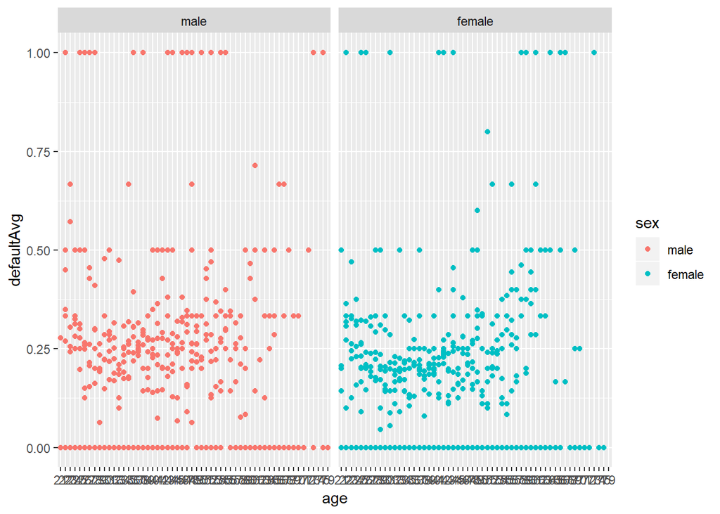

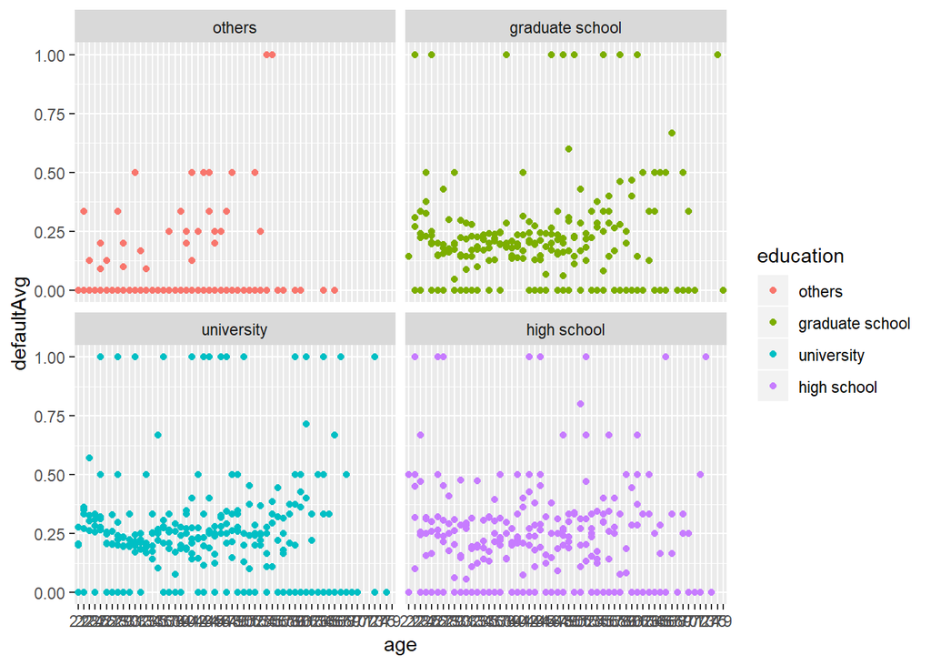

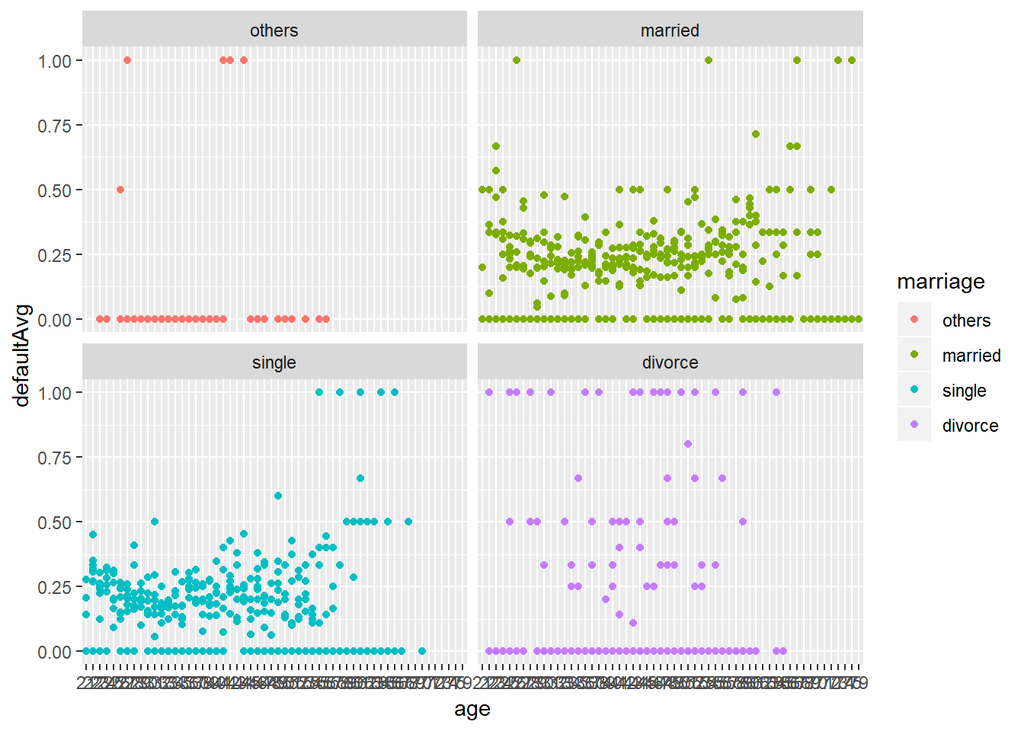

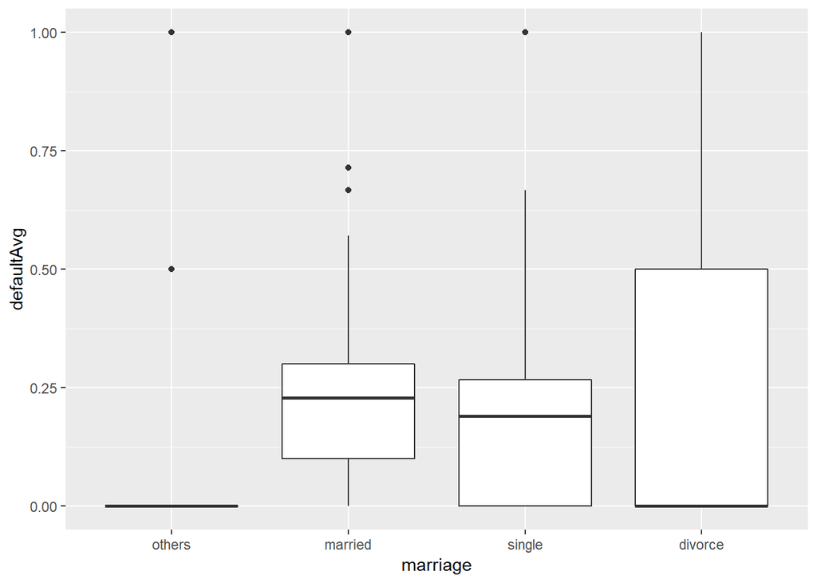

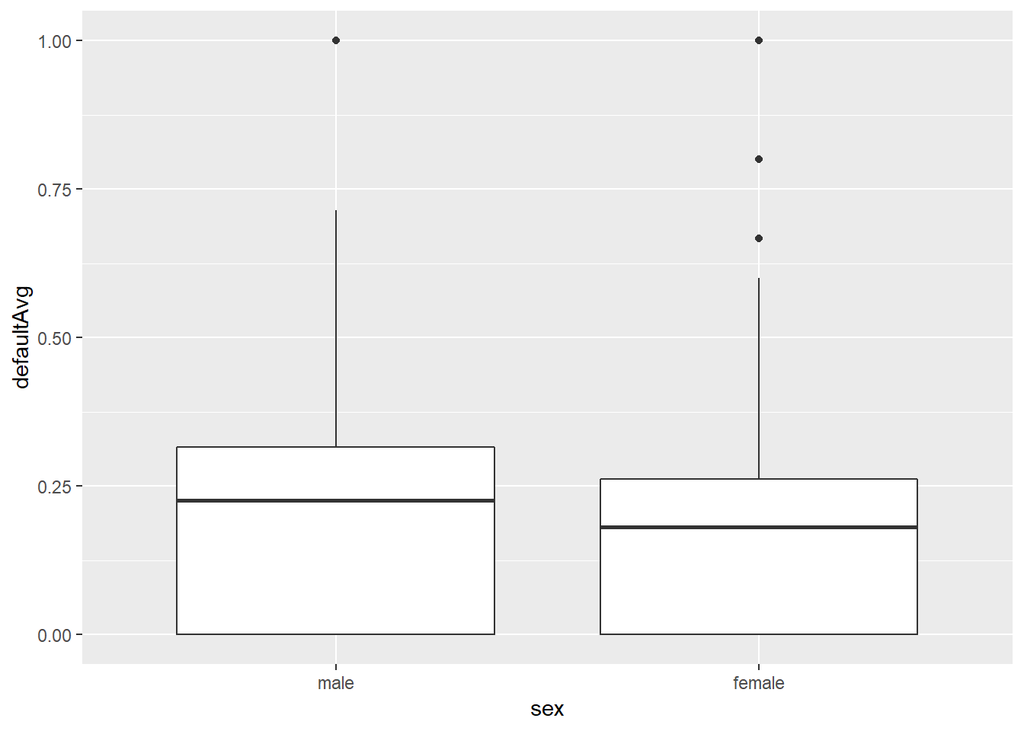

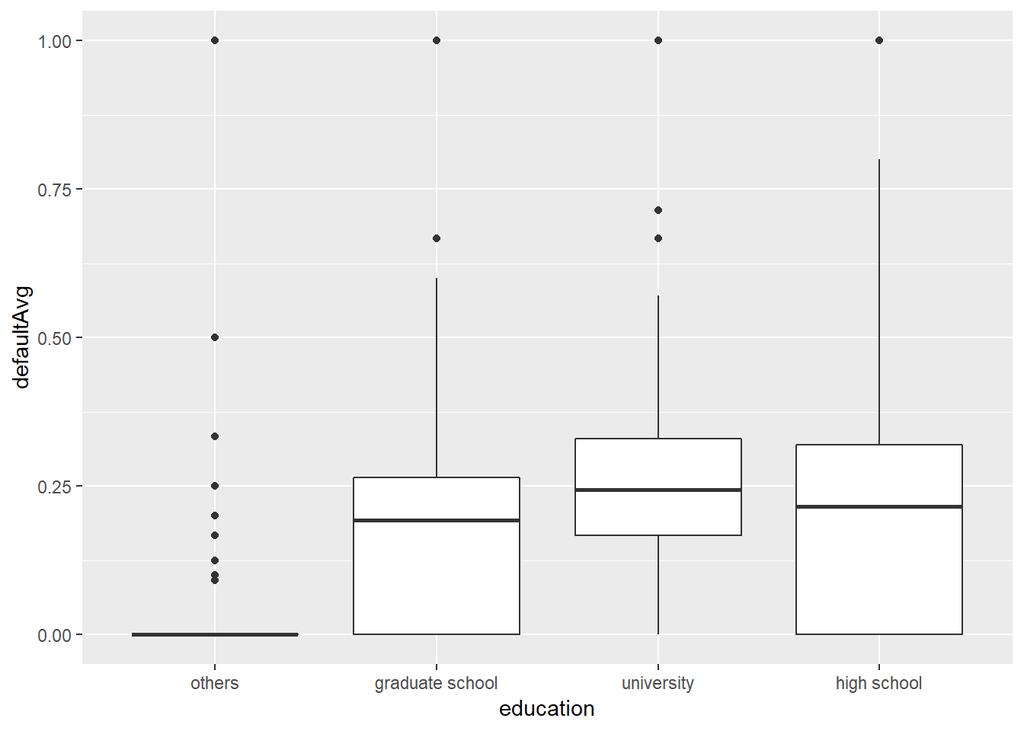

## 資料分析

### T-Test

```r
da<-TB%>%
  group_by(age,sex)%>%
  summarise(defaultAvg = mean(default))
t.test(defaultAvg ~ sex, da)
```

```
##
##  Welch Two Sample t-test
##
## data:  defaultAvg by sex
## t = 1.575, df = 94.068, p-value = 0.1186
## alternative hypothesis: true difference in means is not equal to 0
## 95 percent confidence interval:
##  -0.009067074  0.078635746
## sample estimates:
##   mean in group male mean in group female
##            0.2564257            0.2216414
```

結果: 男女之間的差異不顯著

### ANOVA

#### 教育程度和拖欠

```r
de<-TB%>%
  group_by(age,education)%>%
  summarise(defaultAvg = mean(default))
resulte = aov(defaultAvg~education, de)
summary(resulte)
```

```
##              Df Sum Sq Mean Sq F value   Pr(>F)
## education     3  0.776 0.25862   14.09 2.37e-08 ***
## Residuals   196  3.598 0.01836
## ---
## Signif. codes:  0 '***' 0.001 '**' 0.01 '*' 0.05 '.' 0.1 ' ' 1
```

組間有顯著差異，檢查是哪幾組間差異最顯著

```r
TukeyHSD(resulte)
```

```
##   Tukey multiple comparisons of means
##     95% family-wise confidence level
##
## Fit: aov(formula = defaultAvg ~ education, data = de)
##
## $education
##                                     diff         lwr        upr     p adj
## graduate school-others       0.134227056  0.06120354 0.20725057 0.0000219
## university-others            0.164596455  0.09126732 0.23792559 0.0000001
## high school-others           0.156357218  0.08362921 0.22908523 0.0000005
## university-graduate school   0.030369399 -0.03816107 0.09889987 0.6600729
## high school-graduate school  0.022130163 -0.04575670 0.09001703 0.8330055
## high school-university      -0.008239236 -0.07645474 0.05997626 0.9893500
```

結果: others和其他學歷之間有顯著差異

#### 婚姻狀態和拖欠

```r
dm<-TB%>%
  group_by(age,marriage)%>%
  summarise(defaultAvg = mean(default))
resultm = aov(defaultAvg~marriage, dm)
summary(resultm)
```

```
##              Df Sum Sq Mean Sq F value  Pr(>F)
## marriage      3  0.454 0.15138   5.211 0.00181 **
## Residuals   172  4.997 0.02905
## ---
## Signif. codes:  0 '***' 0.001 '**' 0.01 '*' 0.05 '.' 0.1 ' ' 1
```

組間有顯著差異

```r
TukeyHSD(resultm)
```

```
##   Tukey multiple comparisons of means
##     95% family-wise confidence level
##
## Fit: aov(formula = defaultAvg ~ marriage, data = dm)
##
## $marriage
##                        diff          lwr        upr     p adj
## married-others   0.13767838  0.036517593 0.23883917 0.0029632
## single-others    0.10538768  0.001790961 0.20898440 0.0445045
## divorce-others   0.14771482  0.040956609 0.25447303 0.0024180
## single-married  -0.03229070 -0.118787160 0.05420576 0.7675216
## divorce-married  0.01003644 -0.080222481 0.10029536 0.9916094
## divorce-single   0.04232714 -0.050653767 0.13530804 0.6396603
```

結果: 已婚和離婚與others之間有顯著差異

#### 性別和拖欠

```r
ds<-TB%>%
  group_by(age,sex)%>%
  summarise(defaultAvg = mean(default))
results = aov(defaultAvg~sex, ds)
summary(results)
```

```
##              Df Sum Sq Mean Sq F value Pr(>F)
## sex           1 0.0333 0.03327   2.481  0.118
## Residuals   108 1.4487 0.01341
```

組間沒有顯著差異

```r
TukeyHSD(results)
```

```
##   Tukey multiple comparisons of means
##     95% family-wise confidence level
##
## Fit: aov(formula = defaultAvg ~ sex, data = ds)
##
## $sex
##                    diff         lwr       upr     p adj
## female-male -0.03478434 -0.07856217 0.0089935 0.1181893
```

結果: 男女之間沒有顯著差異

## Model

以年齡分群看教育對拖延還款率之間的關聯

```r
library(Hmisc)

anova(m1 <- lm(defaultAvg ~ education, de))
```

```
## Analysis of Variance Table
##
## Response: defaultAvg
##            Df Sum Sq  Mean Sq F value    Pr(>F)
## education   3 0.7759 0.258620  14.087 2.366e-08 ***
## Residuals 196 3.5984 0.018359
## ---
## Signif. codes:  0 '***' 0.001 '**' 0.01 '*' 0.05 '.' 0.1 ' ' 1
```

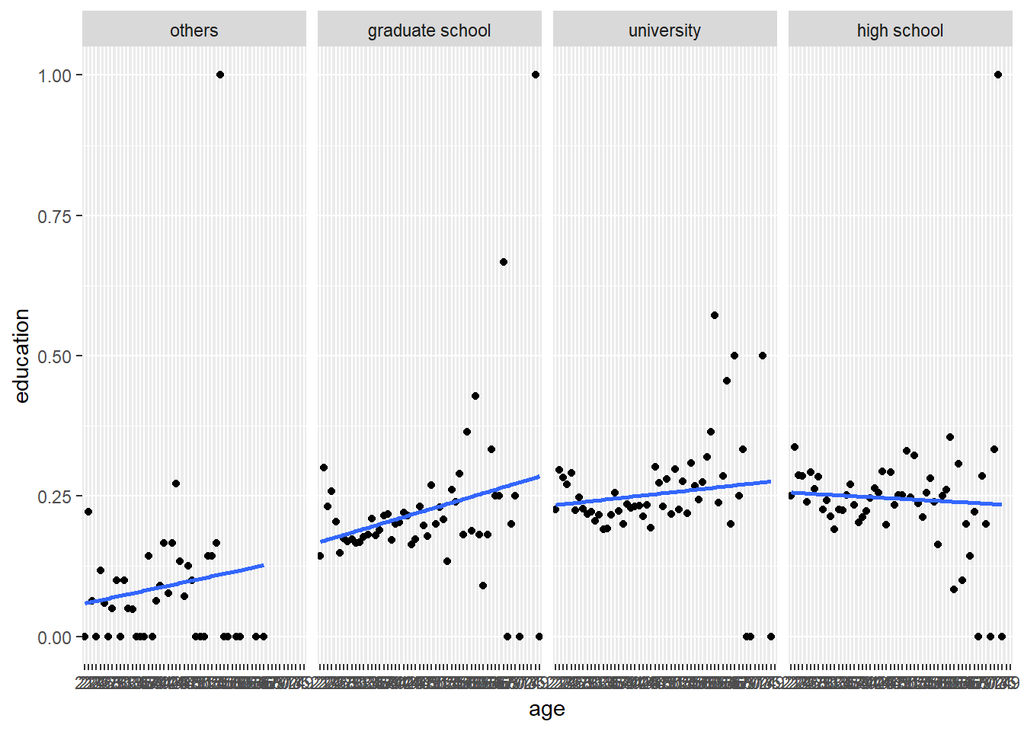

```r
ggplot(de, aes(group = education ,
           y =defaultAvg , x = age )) +
  geom_point() +
  stat_smooth(method = 'lm', se = F) +
  stat_smooth(aes(group = education ,
                  y =defaultAvg , x = age),
              method = 'lm', se = F) +
  facet_grid( . ~  education) +
  labs(x ="age", y = "education" )
```

以年齡分群看婚姻狀態對拖延還款率之間的關聯

```r
anova(m2 <- lm(defaultAvg ~ marriage, dm))
```

```
## Analysis of Variance Table
##
## Response: defaultAvg
##            Df Sum Sq Mean Sq F value   Pr(>F)
## marriage    3 0.4541 0.15138   5.211 0.001812 **
## Residuals 172 4.9966 0.02905
## ---
## Signif. codes:  0 '***' 0.001 '**' 0.01 '*' 0.05 '.' 0.1 ' ' 1
```

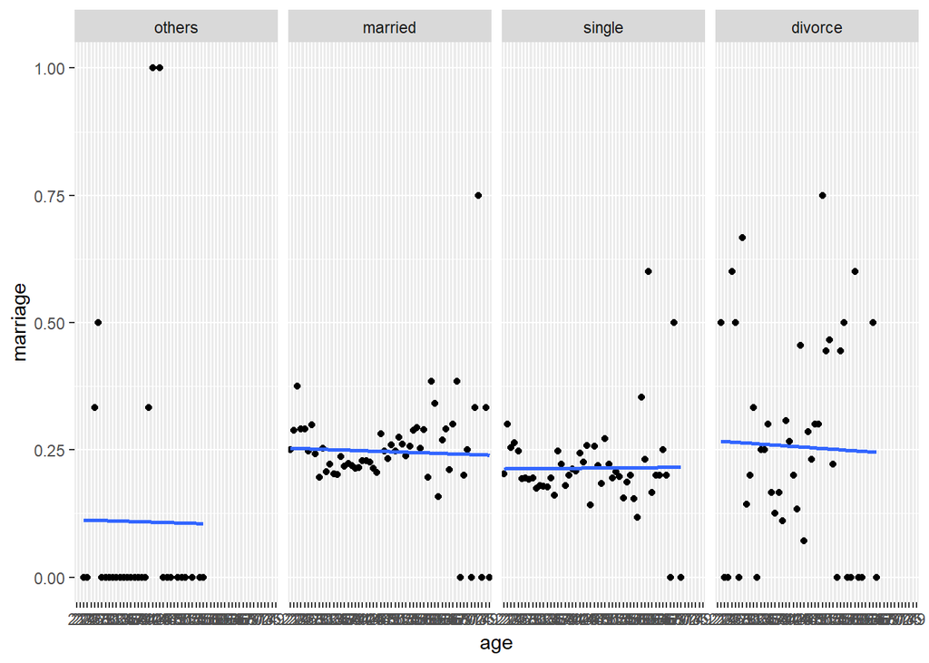

```r
ggplot(dm, aes(group = marriage ,
               y =defaultAvg , x = age )) +
  geom_point() +
  stat_smooth(method = 'lm', se = F) +
  stat_smooth(aes(group = marriage ,
                  y =defaultAvg , x = age),
              method = 'lm', se = F) +
  facet_grid( . ~  marriage) +
  labs(x ="age", y = "marriage" )
```

以年齡分群看性別對拖延還款率之間的關聯

```r
anova(m3 <- lm(defaultAvg ~ sex, ds))
```

```
## Analysis of Variance Table
##
## Response: defaultAvg
##            Df  Sum Sq  Mean Sq F value Pr(>F)
## sex         1 0.03327 0.033274  2.4805 0.1182
## Residuals 108 1.44871 0.013414
```

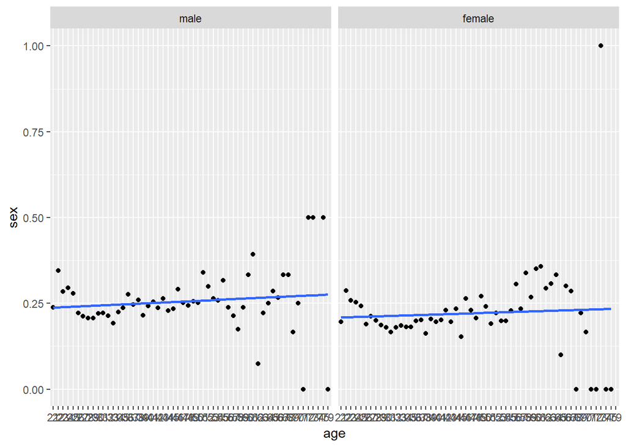

```r
ggplot(ds, aes(group = sex ,
               y =defaultAvg , x = age )) +
  geom_point() +
  stat_smooth(method = 'lm', se = F) +
  stat_smooth(aes(group = sex ,
                  y =defaultAvg , x = age),
              method = 'lm', se = F) +
  facet_grid( . ~  sex) +
  labs(x ="age", y = "sex" )
```